# Spatial Interpolation

2022-11-02

# **The Set-up**

## **Learning objectives.**

1. Load, create, manipulate, and save `Spatial*` and `Raster*` object types in `R`.
2. Perform Non-Geostatistical interpolations in `R`.
3. Perform Geostatistical interpolations in `R`.

## *Before you start*

The practical will be run using *RStudio cloud* to avoid individual machine troubleshooting. This means you **need** to have an account for *RStudio cloud*.

However, remember to have [`R`](https://cran.r-project.org) and [R-studio](http://www.rstudio.com/) in your/room computer so you can work on the project after class.

**You should have also** 1. Read chapter 8 of Bivand Applied Spatial Data Analysis with R

## *The way it’s going to be run*

You will be building and **R-Markdown** document during the class. **R-Markdown** documents allows you to combine your code, its results, and your prose commentary into a single document. If you manage to produce a document your code works. The resulting file (a html) is what you will hand-in at the end of the practical.

## Assessment.

Submit your knitted `R-markdown` file (the HTML) via BrightSpace - **Before the next practical!** **The assessment is a Pass/Fail depending on how you write and annotate the code - You need to show us you know what you are doing and NOT copying someone else’s code.**

# Some basics on interpolation

Almost any variable of interest measured in the field has spatial autocorrelation (i.e., systematic spatial variation in a variable). That can be a problem in statistical tests as it violates a core assumption for most (if not all) statistical tests - independence of observations. However, spatial autocorrelation is a handy feature when the goal is to predict values at locations where no measurements have been made. You can generally safely assume that values at nearby areas will be similar (positively spatially autocorrelated). Several spatial interpolation techniques are geostatistical (Kriging, co-kriging), and others focus on using the location of the network of observations and/or distances between these.

This exercise will focus on generating maps of temperature and precipitation for Denmark at a 1km resolution. Weather-station data from the Danish Meteorological Institute (DMI; https://www.dmi.dk/), collected between 1970 and 2000, will be the baseline information.

# Interpolating Denmark’s weather station data - Generating your own enviormnetal predictors.

## Packages

Before you start doing any analysis, it is necessary to install and load these packages:

1. `maptools`: Tools for Handling Spatial Objects
2. `sp`: Classes and Methods for Spatial Data
3. `rgdal`: Bindings for the ’Geospatial Data Abstraction Library
4. `raster`: Handling geospatial information in raster format
5. `dismo`: Functions for cross-validation procedures
6. `gstat`: Spatial and Spatio-Temporal Geostatistical Modelling
7. `automap`: Automatic kriging interpolation package
8. `fields`: Tools for thin plate spline model

## Weather station data

The first step when doing spatial interpolation is defining the location of the network of observations to use. Here, the network of weather stations owned and managed by DMI will be used. The file `Stations.csv` contains information on the Name, Type, and Location (Lat-Long-Elevation) of DMI owned stations. I extracted this table from the public data available at https://bit.ly/2WeEvTq

Now load the data in `Stations.csv`, and examine the information in the data.frame.

```r
# Location of All the Weather stations
DMI.Stations <- read.csv("https://raw.githubusercontent.com/AlejoOrdonez/StaGeoMod2021/main/StationsWithClim.csv")
# Print the names of the Variables in DMI.Stations
names(DMI.Stations)
```

```
##  [1] "X"                      "StationId"              "Name"
##  [4] "Country"                "Owner"                  "StationType"
##  [7] "Status"                 "StationHeightabvMSL.m." "BarometerHeight..m."
## [10] "Latitude"               "Longitude"              "Region"
## [13] "Operation.From"         "Country.Code"           "StationId.1"
## [16] "MAT.C"                  "AnnPrec.mm.yr"
```

```r
# Print the dimensions in DMI.Stations
dim(DMI.Stations)
```

```
## [1] 211  17
```

You will see that the data.frame is composed of 211 stations (rows), for which a unique id (`StationId`), a station name (`Name`), Station Type (`StationType`), and multiple positional information is available (`Country`, `Latitude`, `Longitude`, `StationHeightabvMSL.m`).

With this information, it is now possible to make a map showing the location of the weather stations in Denmark.

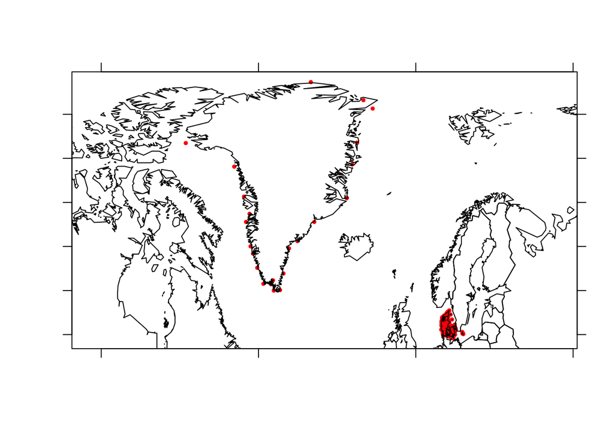

```r
# Load the required library (sp)
library(sp)
# Transform the data.frame into a SpatialPointsDataFrame
DMI.Stations.Shp <- SpatialPointsDataFrame(coords = DMI.Stations[, c("Longitude", "Latitude")],
                                           data = DMI.Stations,
                                           proj4string = CRS("+proj=longlat +datum=WGS84 +no_defs"),
                                           match.ID = TRUE)

# Load the required library (maptools)
library(maptools)
# Load a world map
data(wrld_simpl)

# Plot the location of the weather stations
plot(DMI.Stations.Shp,
   pch = 19, cex = 0.5, col = "red")
# Plot the World map
plot(wrld_simpl, add = T)
# Add a bounding box and some tick marks to define the latitude-longitude point
box(); axis(1, labels = NA); axis(2, labels = NA);  axis(3, labels = NA); axis(4, labels = NA)
```

The map shows the location of DMI stations. These are located both within Denmark and Greenland. The odd point in the ocean is due to the quality of the world vector. Here only stations within Denmark will be used, which means using the `Country` variable in `DMI.Stations` or `DMI.Stations.Shp` to extract the locations in the region of interest.

```r
# Define those observations within Denmark
DK.Sites <- which(DMI.Stations.Shp$Country == "DNK") # DNK is the ISO code for Denmark
# Generate a SpatialPointsDataFrame only for the weather stations in Denmark
DMI.DK.Shp <- DMI.Stations.Shp[DK.Sites, ]
# Print a summary of DMI.DK.Shp
summary(DMI.DK.Shp)
```

```
## Object of class SpatialPointsDataFrame
## Coordinates:
##               min     max
## Longitude  8.0828 15.0953
## Latitude  54.5687 57.7364
## Is projected: FALSE
## proj4string : [+proj=longlat +datum=WGS84 +no_defs]
## Number of points: 185
## Data attributes:
##        X           StationId         Name             Country
##  Min.   :  1.0   Min.   : 5005   Length:185         Length:185
##  1st Qu.: 47.0   1st Qu.: 5406   Class :character   Class :character
##  Median :116.0   Median : 6126   Mode  :character   Mode  :character
##  Mean   :111.3   Mean   :13035
##  3rd Qu.:165.0   3rd Qu.:22189
##  Max.   :211.0   Max.   :32110
##
##     Owner           StationType           Status
##  Length:185         Length:185         Length:185
##  Class :character   Class :character   Class :character
##  Mode  :character   Mode  :character   Mode  :character
##
##
##
##
##  StationHeightabvMSL.m. BarometerHeight..m.    Latitude       Longitude
##  Min.   : 1.50          Min.   : 2.700      Min.   :54.57   Min.   : 8.083
##  1st Qu.: 7.00          1st Qu.: 6.138      1st Qu.:55.29   1st Qu.: 9.159
##  Median :18.00          Median :16.500      Median :55.83   Median :10.107
##  Mean   :26.15          Mean   :24.757      Mean   :55.92   Mean   :10.303
##  3rd Qu.:38.50          3rd Qu.:41.820      3rd Qu.:56.51   3rd Qu.:11.329
##  Max.   :96.00          Max.   :89.200      Max.   :57.74   Max.   :15.095
##  NA's   :70             NA's   :147
##      Region   Operation.From      Country.Code   StationId.1       MAT.C
##  Min.   :6    Length:185         Min.   :6080   Min.   :6019   Min.   :7.900
##  1st Qu.:6    Class :character   1st Qu.:6080   1st Qu.:6074   1st Qu.:8.400
##  Median :6    Mode  :character   Median :6080   Median :6124   Median :8.500
##  Mean   :6                       Mean   :6080   Mean   :6118   Mean   :8.494
##  3rd Qu.:6                       3rd Qu.:6080   3rd Qu.:6158   3rd Qu.:8.700
##  Max.   :6                       Max.   :6080   Max.   :6197   Max.   :9.100
##  NA's   :70                      NA's   :138    NA's   :138    NA's   :1
##  AnnPrec.mm.yr
##  Min.   :523.0
##  1st Qu.:602.8
##  Median :671.0
##  Mean   :691.7
##  3rd Qu.:776.8
##  Max.   :921.0
##  NA's   :1
```

You can now plot a new map using the `DMI.DK.Shp` object to confirm that the extraction was correct. But this time use the fine resolution map for Denmark you can get using the e `getData()` function from the `raster` package

```r
# Load the required package (raster)
library(raster)

# Get the country administrative boundaries for Denmark, Sweden, and Germany.
Denmark <- getData('GADM', country = 'DNK', level = 0, path = './Data')
# Print the summary of Sweden.2
summary(Denmark)
```

```
## Object of class SpatialPolygonsDataFrame
## Coordinates:
##         min      max
## x  8.076389 15.19306
## y 54.559029 57.75153
## Is projected: FALSE
## proj4string : [+proj=longlat +datum=WGS84 +no_defs]
## Data attributes:
##     GID_0              NAME_0
##  Length:1           Length:1
##  Class :character   Class :character
##  Mode  :character   Mode  :character
```

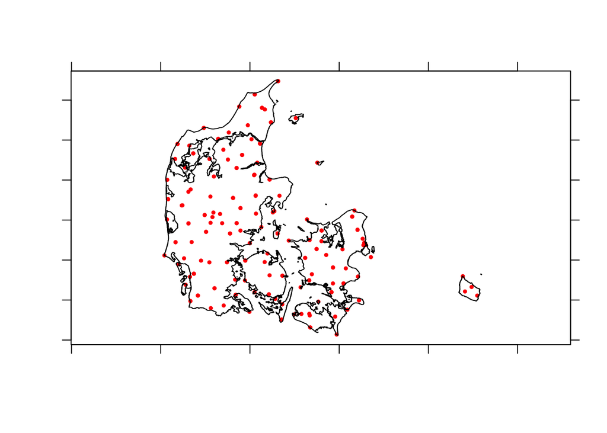

```r
# Plot the location of all the Weather stations
plot(DMI.DK.Shp,
     pch = 19, cex = 0.5, col = "red")
# Plot the World map
plot(Denmark, add = T)
# Add a bounding box and some tick marks to define the latitude-longitude point
box(); axis(1, labels = NA); axis(2, labels = NA);  axis(3, labels = NA); axis(4, labels = NA)
```

## Exploring the climatic information at the weather station sites.

Temperature (measured in C as Mean Annual Temperature, MAT) and precipitation (measures in mm*yr-1 as Total Annual Precipitation, TAP) information for the weather station sites is included in the `StationsWithClim.csv` file, that has been transformed into the `DMI.Stations.Shp` and `DMI.DK.Shp` objects. The values in the file correspond to the average Mean Annual Temperature and Total Annual Precipitation for the 1970 to 2000 period.

However, here you will **ONLY** use the data for Mean Annual Temperature.

As a first step, plot the change in Mean Annual Temperature across the stations in Denmark. For this, first rank the stations according to the variable’s value and then build a scatter plot with `StationId` in the X-Axis and the evaluated climate variable (Mean Annual Temperature) in the Y-axis.

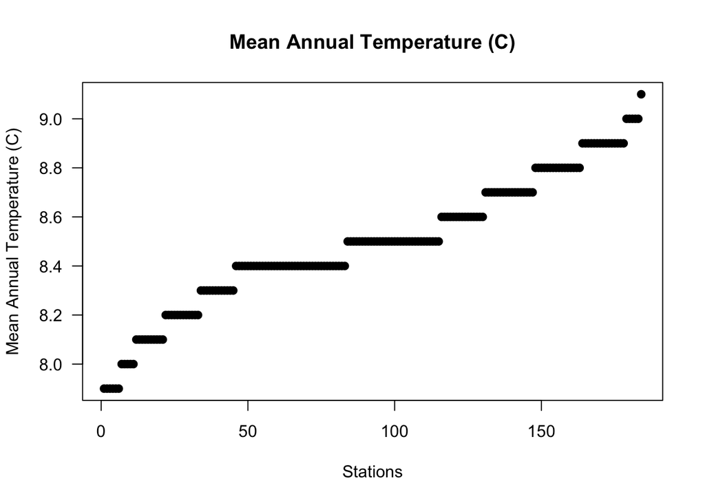

```r
### sort the MAT values
MAT.OrderVct <- sort(DMI.DK.Shp$MAT.C)
### Plot the MAT values
plot(MAT.OrderVct,
     ylab = "Mean Annual Temperature (C)",
     las = 1,
     xlab = "Stations",
     pch = 19,
     main = "Mean Annual Temperature (C)")
```

The figure above shows that there are no stations with “extreme” values or deviate from the regions’ trend of observations. These figures further indicate that the observed climatic space is well constrained. For those interested in exploring the data further, I encourage you to assess how Mean Annual Temperature (C) and Annual precipitation (mm) change as a function of latitude and the Mean Annual Temperature (C) vs. Annual precipitation (mm) climate space.

The question now is *how do these values look on a map?*. You can do this in two ways. The approach you will use here is to plot the `SpatialPointsDataFrame` using the `spplot()` function of the `sp` package.

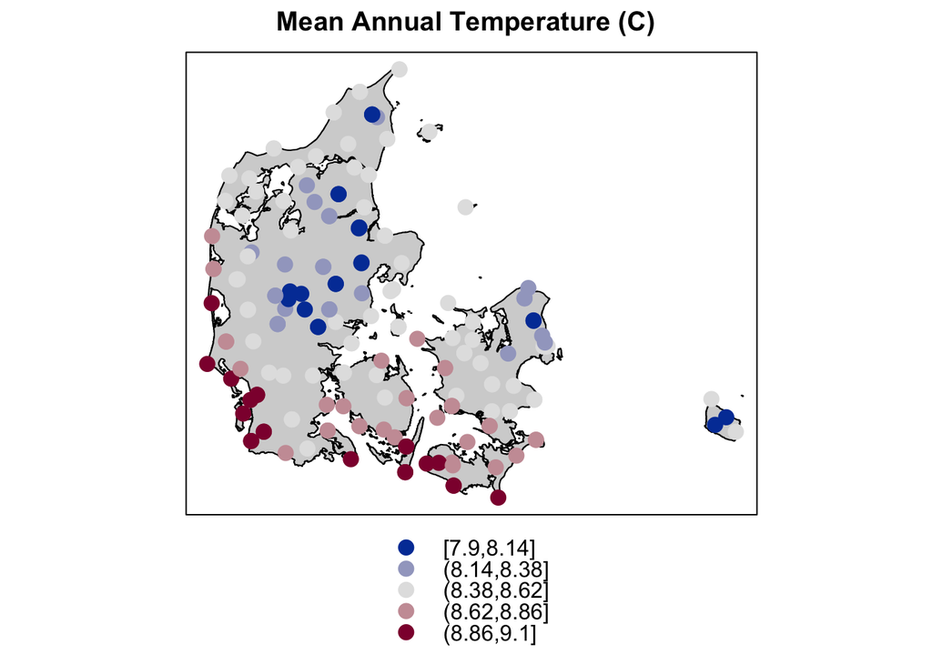

```r
#### Plot the MAT values using the spplot() function
spplot(obj = DMI.DK.Shp,
       zcol = 'MAT.C',
# make sure a colour key is added to the figure
       colourkey = T,
# Determine the colour using a blue to red hcl colour palette
       col.regions = hcl.colors(n = 100,
                                    palette = "Blue-Red"),
# This adds the Polygon to the figure
       sp.layout = list("sp.polygons", Denmark, fill = "lightgray"),
# Type and size of the points
       pch = 20, cex = 2,
       main = "Mean Annual Temperature (C)")
```

```r
# Define the PROJ string
## proj4string of the Lambert azimuthal equal-area projection - the proj* string is <+proj=laea>
DK.UTM <- "+proj=utm +zone=32 +datum=WGS84 +units=m +no_defs +type=crs"

## Project the Weather station locations
DMI.DK.Shp.Proj <- spTransform(x = DMI.DK.Shp,
                               CRSobj = CRS(DK.UTM))
## Project the Denmark Map
Denmark.Proj <- spTransform(x = Denmark,
                            CRSobj = CRS(DK.UTM))
#Denmark2.Proj  <- spTransform(x = wrld_simpl[wrld_simpl$NAME=="Denmark",],
#                            CRSobj = CRS(DK.UTM))
```

## Interpolation - NULL model

From this moment on, the focus will be to interpolate (estimate for locations not sampled) the Mean Annual Temperature values. The simplest way would be to take the mean of all observations, which can be considered a “Null-model”. You can then compare such a model to the other approaches implemented later on. To assess how good is the interpolation, the Root Mean Square Error ($RMSE = \sqrt{\sum_{i = 1}^N (( \hat{x}_i -x_i)^2)/N}$; where $\hat{x}_i$ is the prediction for the i<sup>th</sup> observation, and $N$ is the number of values estimated) will be used as an evaluation statistic.

```r
## Build a function for the Root Mean Square Error
RMSE.Fnc <- function(observed, predicted) {
  sqrt(mean((predicted - observed)^2,
            na.rm = TRUE))
}
```

Now, the null model is estimated by assigning the mean across all weather stations as the “predicted value” to all sampled sites. Then, you will evaluate the RMSE value for this NULL-model, which is the one “all interpolation” approach would need to beat!

```r
## Null MAT - Assign the mean across weather stations as the predicted MAT
DMI.DK.Shp.Proj$Null.MAT <- mean(DMI.DK.Shp.Proj$MAT.C,
                                 na.rm = T)

# Estimate the Root Mean Square Error for the NULL-MAT model using the RMSE.Fnc function created above
null.RMSE.MAT <- RMSE.Fnc(observed = DMI.DK.Shp.Proj$MAT.C,
                          predicted = DMI.DK.Shp.Proj$Null.MAT)
# Print the RMSE
null.RMSE.MAT
```

```
## [1] 0.2680792
```

With the Null model, you have a benchmark to beat. Think of this as the same as when you execute a model selection procedure. You define the perforce of a model with **NO** predictors as the benchmark to decide if your models are doing a good job.

## Interpolation - Inverse Distance interpolation (IDW)

Inverse distance weighting (IDW) is a non-geostatistical method for spatial interpolation with a known scattered set of points. The technique makes the explicit assumption that things that are close to one another are more alike than those that are farther apart. To predict a value for any unmeasured location, IDW uses the measured values surrounding the prediction location. The measured values closest to the prediction location have more influence on the predicted value than those farther away. IDW assumes that each measured point has a local influence that diminishes with distance. It gives greater weights to points closest to the prediction location, and the weights decrease as a function of distance; hence the name inverse distance weighted.

A a `gstat` object (created using the `gstat()` function of the `gstat` package) and the `interpolate()` function of the `raster` package can be used for this. The `gstat` object should be specified using an “intercept only” model (`. ~1`) - in the case of spatial data, this means that only the positions (‘x’, and ‘y’ coordinates) are used in the definition of the model. A possibility when implementing an IDW using a `gstat` object is that you can define a maximum number of points (here, ten for simplicity). Also, you can specify the “inverse distance power” (the rate at which the weights decrease is dependent on the distance between points) with the `idp` argument (here, it is set to zero such that all ten neighbours are equally weighted).

```r
# Load the Library
library(gstat)

# Create a gstat object for MAT
gs.MAT <- gstat(formula = MAT.C ~ 1, # Formula
# Note that NA values in DMI.DK.Shp.Proj has been removed as the interpolate function below doe not allow NA values
                locations = DMI.DK.Shp.Proj[!is.na(DMI.DK.Shp.Proj$MAT.C), ],
 # define the Neighbourhood (5 points)
                nmax = 10,
# set the inverse distance power top Zero
                set = list(idp = 0))

## The interpolate() function needs a raster template into which values are predicted - here you use the 1km Raster
DK.Rast1km <- raster(Denmark.Proj, res = 1000) # why 1000? because the units are m

# interpolate
IDW.MAT.1km <- interpolate(object = DK.Rast1km, # The raster template
                           model = gs.MAT # The gstat model
                           )
```

```
## [inverse distance weighted interpolation]
```

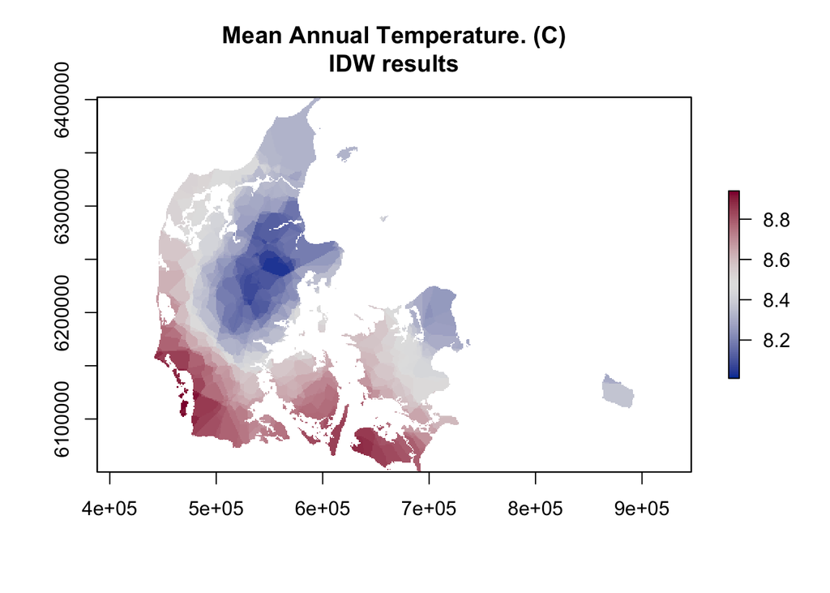

```r
IDW.MAT.1km <- mask(x = IDW.MAT.1km,  # The IDW interpolated raster
                    mask = Denmark.Proj # The Spatial object used to "mask" the IDW interpolated raster
                    )
plot(IDW.MAT.1km, # The "masked" the IDW interpolated raster
     col = hcl.colors(n = 100, palette = "Blue-Red"),
     main = c("Mean Annual Temperature. (C)\nIDW results"))
```

The quality of the prediction can be evaluated using a cross-validation approach. For this you will use a 5-fold cross-validation is used using the `kfold()` function of the package `dismo`. The objective here is to define to which fold does an observation belong.

```r
## Evaluate with 5-fold cross validation.
set.seed(5132015)
# Load the required library (dismo)
library(dismo)
# using the `kfold()` function of the package `dismo` each observation is placed into a cross validation fold.

kf <- kfold(x = DMI.DK.Shp.Proj,# The spatial object used to define the train/test dataset
            k = 5 # Number of groups
            )
## Build a vector to store the Root Mean Square Errors
RMSE.IDW.MAT <- rep(NA, 5)
# Loop across the five k-folds
for (k in 1:5) {
# Create a Test Data.frame
   test <- DMI.DK.Shp.Proj[kf == k, ]
# Create a Train Data.frame
   train <- DMI.DK.Shp.Proj[kf != k, ]
# build a gstat model for the interpolation
   gs <- gstat(formula = MAT.C~1,
               locations = train[!is.na(train$MAT.C), ],
# define the Neighbourhood (5 points)
               nmax = 10,
# set the inverse distance power top Zero
               set = list(idp = 0))
# Note that you can use the predict method to get predictions for the locations of the test points instead of generating new maps using interpolate
   p <- predict(gs, test)
   RMSE.IDW.MAT[k] <- RMSE.Fnc(test$MAT.C,
                               p$var1.pred)
}
```

```
## [inverse distance weighted interpolation]
## [inverse distance weighted interpolation]
## [inverse distance weighted interpolation]
## [inverse distance weighted interpolation]
## [inverse distance weighted interpolation]
```

```r
# print the Root Mean Square Error for each fold
RMSE.IDW.MAT
```

```
## [1] 0.18781100 0.14695099 0.11099299 0.10186106 0.09179884
```

```r
#The Mean Root Mean Square Error
mean(RMSE.IDW.MAT)
```

```
## [1] 0.127883
```

```r
## How much of an improvement over the null model is seen
(RMSE.IDW.MAT.Imp <- 1 - (mean(RMSE.IDW.MAT) / null.RMSE.MAT))
```

```
## [1] 0.5229656
```

The IDW interpolation of Mean Annual Temperature is approximately ~52% better than the Null-model.

## Interpolation - Thin-plate spline model (TPS)

Thin plate splines (TPS) are a non-geostatistical technique for data interpolation and smoothing. The name thin-plate spline refers to a physical analogy involving the bending of a thin sheet of metal. Just as the metal has rigidity, the TPS fit resists bending, implying a penalty involving the smoothness of the fitted surface. In the physical setting, the deflection is in the z-direction, orthogonal to the plane. To apply this idea to the problem of coordinate transformation, one interprets the lifting of the plate as a displacement of the x or y coordinates within the plane as a polynomial function of $2*(K = 3)$ parameters (as implemented in the `Tps()` function of the `fields` package. As a technique, it was the approach used by WorldClim V1.4.

The implementation of the method is straightforward using the `Tps()` function of the `fields` package. Below, the process is shown for both Mean Annual Temperature.

```r
# Load the required library (fields)
library(fields)
# Estimate a thin plate spline model for MAT
# Build the thin plate model
TPS.MAT <- Tps(x = coordinates(DMI.DK.Shp.Proj), # Matrix of independent variables
               Y = DMI.DK.Shp.Proj$MAT.C # Vector of dependent variables
               )
TPS.MAT
```

```
## Call:
## Tps(x = coordinates(DMI.DK.Shp.Proj), Y = DMI.DK.Shp.Proj$MAT.C)
##
##  Number of Observations:                184
##  Number of parameters in the null space 3
##  Parameters for fixed spatial drift     3
##  Model degrees of freedom:              158.7
##  Residual degrees of freedom:           25.3
##  GCV estimate for tau:                  1.961e-05
##  MLE for tau:                           9.597e-05
##  MLE for sigma:                         95.79
##  lambda                                 9.6e-11
##  User supplied sigma                    NA
##  User supplied tau^2                    NA
## Summary of estimates:
##                  lambda    trA          GCV       tauHat -lnLike Prof converge
## GCV        9.614603e-11 158.65 2.334478e-08 1.960803e-05    -296.8812       NA
## GCV.model  9.614603e-11 158.65 2.334478e-08 1.960803e-05           NA       NA
## GCV.one    9.614603e-11 158.65 2.790666e-09 1.960803e-05           NA       NA
## RMSE                 NA     NA           NA           NA           NA       NA
## pure error 9.614603e-11 158.65 2.334478e-08 1.960803e-05    -296.8812       NA
## REML       9.614603e-11 158.65 2.334478e-08 1.960803e-05    -296.8812       NA
```

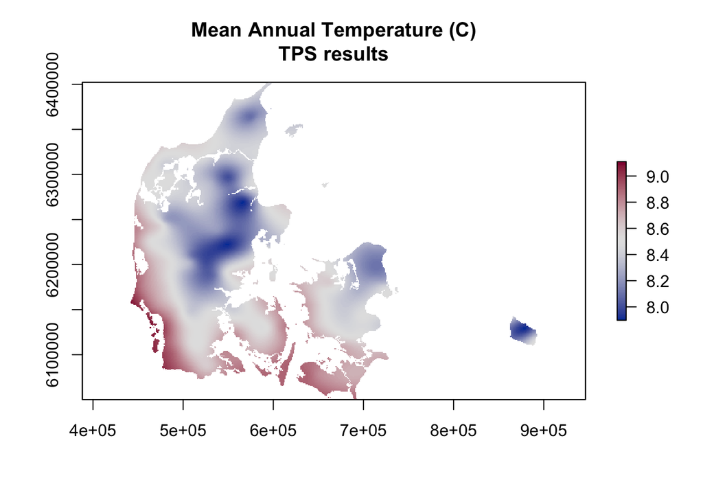

```r
# Generate a prediction of the model using the `interpolate()` function from the raster package.
TPS.MAT.Pred <- interpolate(object = raster(DK.Rast1km), # Baseline Raster* object.
                            model = TPS.MAT # The TPS model to generate new predictions.
                            )
# Mask out all the areas outside the landmass of Denmark
TPS.MAT.Pred <- mask(x = TPS.MAT.Pred, # The interpolated raster
                     mask = Denmark.Proj # An spatial object to crop the oceans.
                     )
# Plot the TPS model
plot(TPS.MAT.Pred,
     col = hcl.colors(n = 100, palette = "Blue-Red"),
     main = 'Mean Annual Temperature (C)\nTPS results')
```

```r
## Evaluate with 5-fold cross validation for MAT.
set.seed(5132015)
# using the `kfold()` function of the package `dismo` each observation is placed into a cross validation fold.
kf <- kfold(x = DMI.DK.Shp.Proj, # The spatial object used to define the train/test dataset
            k = 5 # Number of groups
            )
## Build a vector to store the Root Mean Square Errors
RMSE.TPS.MAT <- rep(NA, 5)
# Loop across the five k-folds
for (k in 1:5) {
# Create a Test Data.frame
   test <- DMI.DK.Shp.Proj[kf == k, ]
# Create a Train Data.frame
   train <- DMI.DK.Shp.Proj[kf != k, ]
# build a Tps model for the interpolation
   Tps.mod <- Tps(x = coordinates(train), # Matrix of locations
                  Y = train$MAT.C, # Vector of response variables on the locations
                  verbose = F)
# Note that you can use the predict method to get predictions for the locations of the test points instead of generating new maps using interpolate
  p <- predict(Tps.mod, coordinates(test))
  RMSE.TPS.MAT[k] <- RMSE.Fnc(test$MAT.C,
                              p)
}
# print the Root Mean Square Error for each fold
RMSE.TPS.MAT
```

```
## [1] 0.09040984 0.10942764 0.15446078 0.13914717 0.06002568
```

```r
#The Mean Root Mean Square Error
mean(RMSE.TPS.MAT)
```

```
## [1] 0.1106942
```

```r
## How much of an improvement over the null model is seen
(RMSE.TPS.MAT.Imp <- 1 - (mean(RMSE.TPS.MAT) / null.RMSE.MAT))
```

```
## [1] 0.5870838
```

## Interpolation - Geostatistical interpolation - Kriging

You can use kriging techniques to describe and model spatial patterns, predict values at unmeasured locations, and assess the uncertainty associated with a predicted value at the unmeasured locations. This widely applied geostatistical interpolation method interpolate the variable of interest to the unknown location using a model that describes the spatial behaviour of the phenomenon of interest. Kriging assumes that at least some of the spatial variation observed in natural phenomena can be modelled by random processes with spatial autocorrelation. Therefore, this approach requires explicitly modelling the spatial autocorrelation (via the correlogram/semivariogram).

The functions to execute a Kriging interpolation are part of the `gstat` package. These include the functions: `variogram` to estimate the covariance between observations, `fit.variogram` to estimate the experimental variogram (the mathematical model describing the semivariogram), and `krige` to execute a Kriging interpolation based on a specified function, and a variogram.

Before starting, it is necessary to ensure no duplicate locations, as Kriging does work under these conditions. You can evaluate this using the `zerodist()` function from the `sp` package.

```r
## Test for Zero distance between points
zerodist(DMI.DK.Shp.Proj)
```

```
##       [,1] [,2]
##  [1,]   50  119
##  [2,]   53  123
##  [3,]   56  126
##  [4,]   63  132
##  [5,]   67  134
##  [6,]   71  137
##  [7,]   75  140
##  [8,]   81  148
##  [9,]   90  157
## [10,]   94  161
## [11,]   95  162
## [12,]  100  168
## [13,]  101  169
## [14,]  102  170
## [15,]  104  174
## [16,]  105  177
## [17,]   42  182
```

```r
## Remove duplicate points
DMI.DK.Shp.Proj2 <- DMI.DK.Shp.Proj[-zerodist(DMI.DK.Shp.Proj)[, 1], ]
## Test for Zero distance between points
zerodist(DMI.DK.Shp.Proj2)
```

```
##      [,1] [,2]
```

Now with a dataset without duplicates, the first step in Kriging is generating a variogram. The first one will be for Mean Annual Temperature.

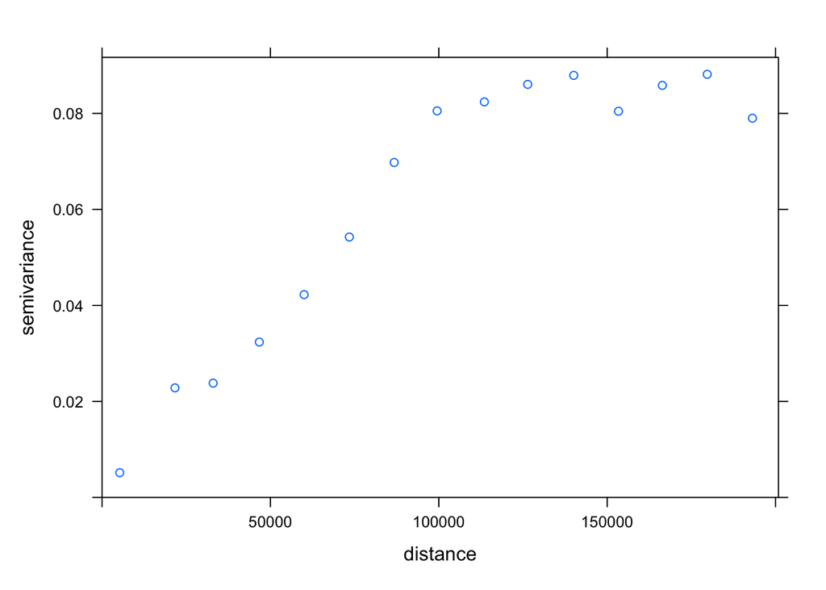

```r
# Generating a gstat for MAT
MAT.gstat <- gstat(formula = MAT.C~1,
                   locations = DMI.DK.Shp.Proj2[!is.na(DMI.DK.Shp.Proj2$MAT.C), ])

# Generating a variogram for MAT
MAT.Variog <- variogram(MAT.gstat,
# cut-off = spatial separation distance up to which point pairs are included
# Here 200000m (200km) as this the the distance until which most of the observations are
                       cutoff = 200000)
plot(MAT.Variog)
```

The plot above indicates the Spherical trend for Mean Annual Temperature.

The question is, which are the best initial values to generate your experimental variograms. Suppose you have a good idea of these values based on the sample variogram. In that case, the experimental variogram for Mean Annual Temperature can be fitted using the `fit.variogram()` function of the `gstat` package. An alternative is to use the `autofitVariogram()` function of the `automap` package to automatically fitting a variogram to the data on which it is applied. You will use this approach below.

```r
# Load the required library(automap)
library(automap)
# Generate the Experimental variogram model for MAT
MAT.Exp.Variog <-autofitVariogram(formula = MAT.C~1,
                                  input_data = DMI.DK.Shp.Proj2[!is.na(DMI.DK.Shp.Proj2$MAT.C), ],
                                  model = c("Sph", "Exp", "Gau", "Nug", "Lin"))
MAT.Exp.Variog
```

```
## $exp_var
##      np        dist        gamma dir.hor dir.ver   id
## 1    53    739.3886 0.0006603774       0       0 var1
## 2     8   5758.0667 0.0062500000       0       0 var1
## 3    19  10282.2742 0.0144736842       0       0 var1
## 4    63  14930.5789 0.0236507937       0       0 var1
## 5   142  21367.4335 0.0228521127       0       0 var1
## 6   179  26815.2096 0.0210335196       0       0 var1
## 7   759  40462.5296 0.0286890646       0       0 var1
## 8   958  60011.6236 0.0429801670       0       0 var1
## 9  1833  85169.9468 0.0664702673       0       0 var1
## 10 1843 114572.2225 0.0848046663       0       0 var1
## 11 1716 143911.4944 0.0841113054       0       0 var1
## 12 2331 178343.1959 0.0844809095       0       0 var1
##
## $var_model
##   model        psill    range
## 1   Nug 7.122152e-05      0.0
## 2   Sph 8.677042e-02 154735.4
##
## $sserr
## [1] NA
##
## attr(,"class")
## [1] "autofitVariogram" "list"
```

Based on the output above, the experimental variogram model for the Mean Annual Temperature is Spherical. One way to assess the fit of the experimental variogram is to plot both the variogram and the model. As seen below, the models appear to fit the data relatively well.

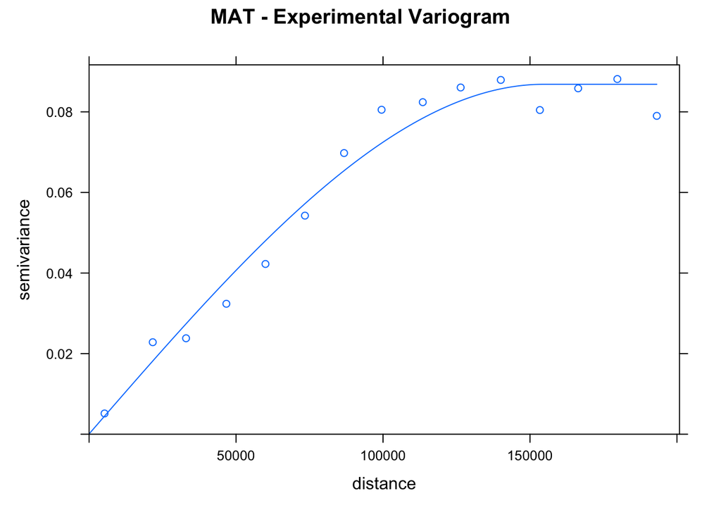

```r
# Plot the MAT variogram and the model plot
plot(MAT.Variog,
     MAT.Exp.Variog[[2]],
     main = "MAT - Experimental Variogram")
```

Now, all the parts to implement a kriging interpolation for Mean Annual Temperature are available.You will use the `krige()` function of the `gstat` package, using as inputs the formula, locations, experimental variogram, and a new `SpatialGrid` to define the space where the interpolation will take place.

```r
# Create a Spatial grid as a template
DK.SpaGrid.1km <- DK.Rast1km
DK.SpaGrid.1km[] <- 1
# Mask out the ocean
DK.SpaGrid.1km <- mask(DK.SpaGrid.1km,
                       Denmark.Proj)
## transform to a Spatial grid
DK.SpaGrid.1km <- as(DK.SpaGrid.1km,
                     'SpatialGridDataFrame')

# use the krige function of gstat, that needs a  model, data, prediction space, and variogram
Pred.gstat.MAT<- krige(formula = MAT.C~1,
                       locations = DMI.DK.Shp.Proj2[!is.na(DMI.DK.Shp.Proj2$MAT.C), ],
                       newdata = DK.SpaGrid.1km,
                       model = MAT.Exp.Variog[[2]])
```

```
## [using ordinary kriging]
```

```r
head(Pred.gstat.MAT)
```

```
##   var1.pred var1.var
## 1        NA       NA
## 2        NA       NA
## 3        NA       NA
## 4        NA       NA
## 5        NA       NA
## 6        NA       NA
```

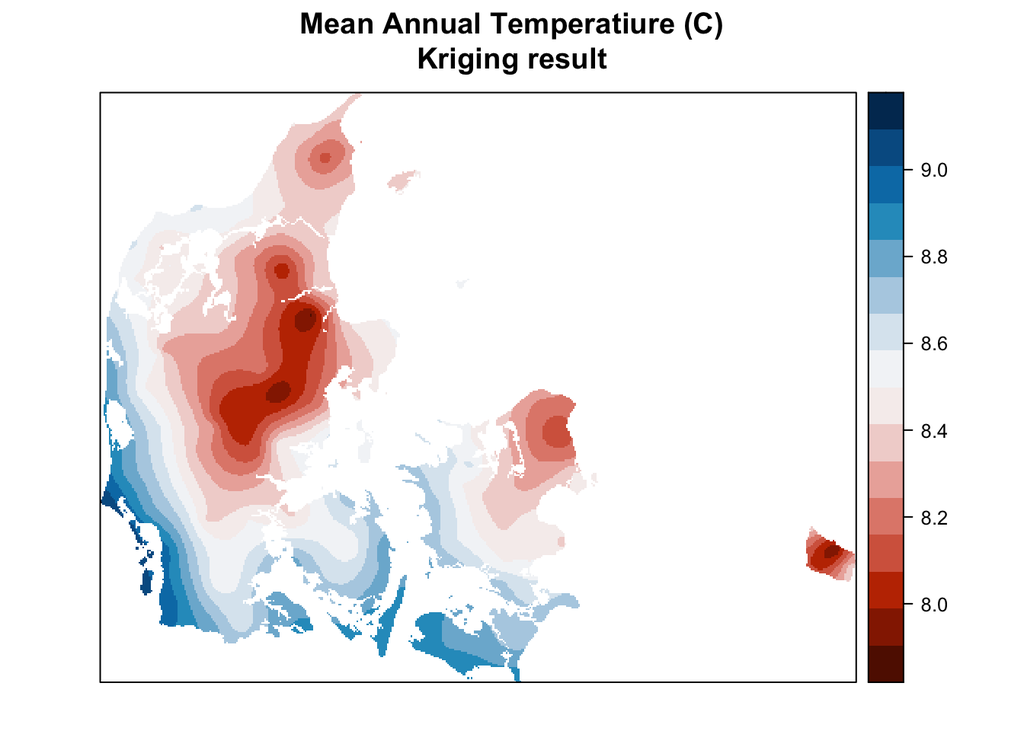

```r
## Plot the predicted values
spplot(obj = Pred.gstat.MAT,
       zcol = "var1.pred",
       col.regions = hcl.colors(n = 100, palette = "RdBu"),
       main = 'Mean Annual Temperatiure (C)\nKriging result')
```

These predictions can be transformed into a `raster` object using the `raster()` function for a single layer or the `brick()` function for multiple layers. Doing this would facilitate the contrast to other models.

```r
# Transform the SpatialGridDataFrame of MAT kriging predictions to a RasterBrick
Krig.MAT.Brick <- brick(Pred.gstat.MAT)
Krig.MAT.Brick
```

```
## class      : RasterBrick
## dimensions : 352, 451, 158752, 2  (nrow, ncol, ncell, nlayers)
## resolution : 1000, 1000  (x, y)
## extent     : 441745.6, 892745.6, 6050207, 6402207  (xmin, xmax, ymin, ymax)
## crs        : +proj=utm +zone=32 +datum=WGS84 +units=m +no_defs
## source     : memory
## names      :    var1.pred,     var1.var
## min values : 7.9025184934, 0.0001430424
## max values :   9.09418524,   0.02355359
```

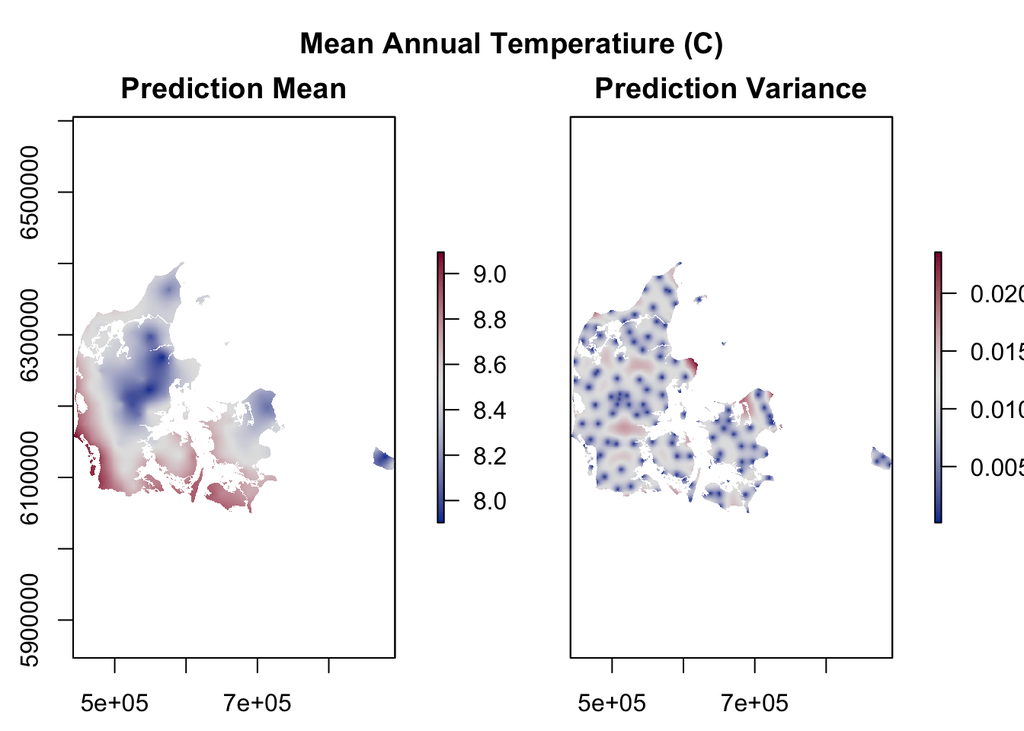

```r
## Plot the Raster
par(oma = c(0.5, 0.5, 2, 0.5))
plot(Krig.MAT.Brick,
     main = c('Prediction Mean', "Prediction Variance"),
     col = hcl.colors(n = 100, palette = "Blue-Red"))
mtext('Mean Annual Temperatiure (C)',
      outer = T, cex = 1.2, font = 2)
```

Last, a cross-validation assessment of the RMSE of the Kriging interpolation can be done using either an n-fold or a leave one out approach. This can be done automatically using either the `krige.cv()` function of the `gstat` package, or the `autoKrige()` function of the `automap` package. Below, the implementation of the `krige.cv()` function is presented.

```r
### MAT Kriging Cross-validation
Cros.Val.MAT<- krige.cv(formula = MAT.C~1,
                        locations = DMI.DK.Shp.Proj2[!is.na(DMI.DK.Shp.Proj2$MAT.C), ],
                        nfold = 5,  # Define the number of folds
                        model = MAT.Exp.Variog[[2]])
# Print the Cross-validation OBJECT
Cros.Val.MAT
```

```
## class       : SpatialPointsDataFrame
## features    : 167
## extent      : 442145.3, 889113.8, 6050782, 6400533  (xmin, xmax, ymin, ymax)
## crs         : +proj=utm +zone=32 +datum=WGS84 +units=m +no_defs
## variables   : 6
## names       :        var1.pred,             var1.var, observed,           residual,            zscore, fold
## min values  : 7.90173861511975, 0.000151551165579804,      7.9, -0.533524189097982, -3.07656961498093,    1
## max values  : 9.00444683929262,   0.0537770456350038,      9.1,  0.432058660861445,  2.61321165342515,    5
```

```r
# Estimate the RMSE for each of the Cross-validated fold
RMSE.Kig.MAT <- sapply(1:5 , function(i){
  RMSE.Fnc(observed = DMI.DK.Shp.Proj2[!is.na(DMI.DK.Shp.Proj2$MAT.C), ][Cros.Val.MAT$fold == i, ]$MAT.C,
           predicted = Cros.Val.MAT$var1.pred[Cros.Val.MAT$fold == i])
})
# print the Root Mean Square Error for each fold
RMSE.Kig.MAT
```

```
## [1] 0.10648723 0.13674591 0.08723400 0.09193194 0.05864343
```

```r
#The Mean Root Mean Square Error
mean(RMSE.Kig.MAT)
```

```
## [1] 0.0962085
```

```r
## How much of an improvement over the null model is seen
(RMSE.Kig.MAT.Imp <- (1 - (mean(RMSE.Kig.MAT) / null.RMSE.MAT)))
```

```
## [1] 0.6411191
```

## Comparision across methods

The question now is which method to use?. One way to assess this is to determine which one has a more considerable increase in the RMSE when compared to a Null Expectation.

```r
RMSE.sum <- data.frame(Model = c("IDW", "TPS", "OK"),
# Relative Increase in MAT prediction performance when compared to the Null Model [null.RMSE.MAT]
                        MAT.Imp = c(RMSE.IDW.MAT.Imp,
                                    RMSE.TPS.MAT.Imp,
                                    RMSE.Kig.MAT.Imp)
                )
RMSE.sum
```

```
##   Model   MAT.Imp
## 1   IDW 0.5229656
## 2   TPS 0.5870838
## 3    OK 0.6411191
```

Based on this table, the best interpolation technique for Mean Annual Temperature is the Ordinary Kriging approach, followed by the Thin-Plate Spline approach.

```r
# Generate a Data.frame with the average cross-validation RMSE Values
RMSE.w <- data.frame(Model = c("IDW", "TPS", "OK"),
           MAT.RMSE = c(mean(RMSE.IDW.MAT),
                        mean(RMSE.TPS.MAT),
                        mean(RMSE.Kig.MAT)))
# Generate a Data.frame with Weighs (The proportion of the sum of RMSE)
RMSE.w <- data.frame(Model = c("IDW", "TPS", "OK"),
                     MAT.RMSE = RMSE.w[, 2]/sum(RMSE.w[, 2]))
RMSE.w
```

```
##   Model  MAT.RMSE
## 1   IDW 0.3819846
## 2   TPS 0.3306420
## 3    OK 0.2873734
```

With these weights vectors, it is possible to generate an ensemble model by multiplying each prediction by the weights of the model type. For this, the first step is developing a `RasterStack` with the forecasts for each model.

```r
# Generate a RasterStack with the MAT predictions
MAT.Stack <- stack(IDW.MAT.1km,
                   TPS.MAT.Pred,
# the 1 subscript is to only extract the predictions
                   Krig.MAT.Brick[[1]])
# Give names to the layers
names(MAT.Stack) <- c("IDW" , "TPS", "Krig")
MAT.Stack
```

```
## class      : RasterStack
## dimensions : 352, 451, 158752, 3  (nrow, ncol, ncell, nlayers)
## resolution : 1000, 1000  (x, y)
## extent     : 441745.6, 892745.6, 6050207, 6402207  (xmin, xmax, ymin, ymax)
## crs        : +proj=utm +zone=32 +datum=WGS84 +units=m +no_defs
## names      :      IDW,      TPS,     Krig
## min values : 8.010000, 7.897353, 7.902518
## max values : 8.940000, 9.109740, 9.094185
```

With the `RasterStack`s generated above, it is possible to make an ensemble model by multiplying each prediction by its weight and then summing across models.

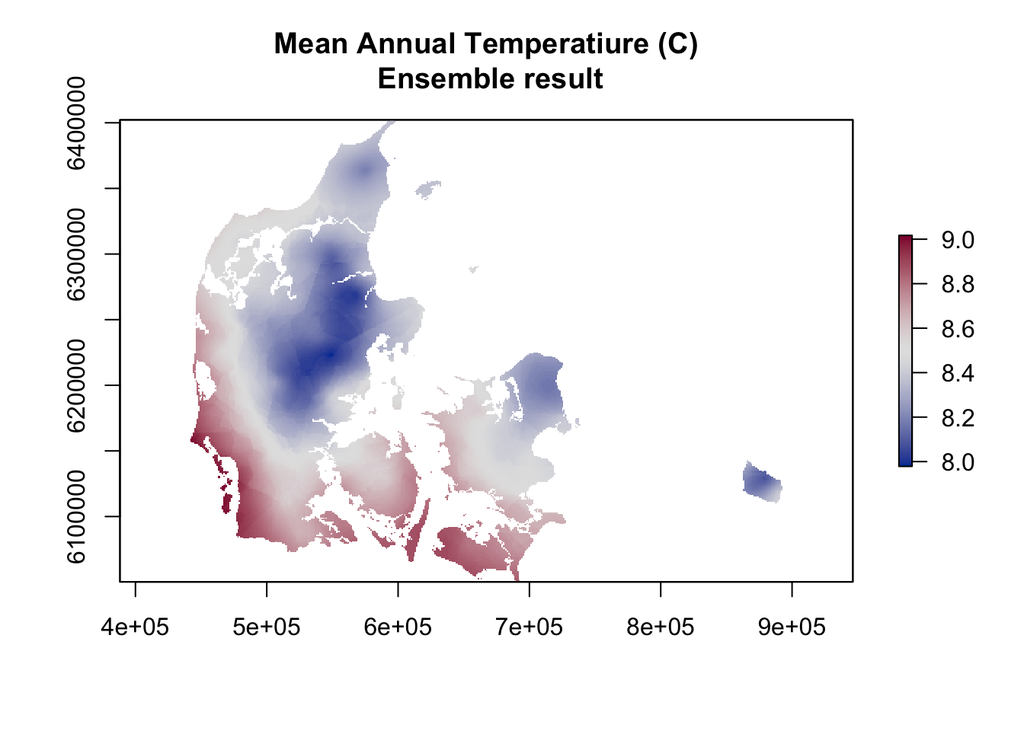

```r
# Generate an ensemble prediction for MAT
MAT.Ensembl <- sum(MAT.Stack*RMSE.w$MAT.RMSE)
plot(MAT.Ensembl,
     col = hcl.colors(n = 100, palette = "Blue-Red"),
     main = c('Mean Annual Temperatiure (C)\n Ensemble result'))
```